# NHS Borders Cancer Analysis

This analysis looks at cancer incidence in the NHS Borders region and makes comparisons with data for Scotland as a whole.

Data is sourced from https://www.opendata.nhs.scot/

### Summary

#### 1. Number of cancer registrations

The number of cancer registrations in NHS Borders has increased between 1995 and 2019.

The plots below show that the pattern of change in NHS Borders is similar to that in Scotland as a whole.

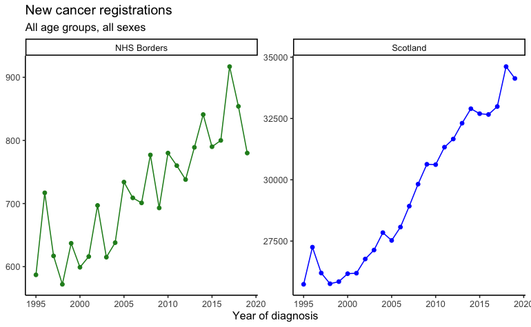

From the table below it can be seen that the incidence of cancer in NHS Borders and Scotland increased by c33% between 1995 and 2019.

| area | cancer_site | year | incidences_all_ages |
| --- | --- | --- | --- |
| NHS Borders | All cancer types | 1995 | 587 |
| NHS Borders | All cancer types | 2019 | 780 |
| Scotland | All cancer types | 1995 | 25737 |
| Scotland | All cancer types | 2019 | 34133 |

#### 2. Cancer registrations by age band

The plots below show the total number of cancer registrations between 2015 and 2019, grouped by age band. New diagnoses are heavily skewed towards older ages (50+), with the most occuring in the 65 to 79 group.

A visual inspection suggests that the age distribution in NHS Borders is very similar to Scotland as a whole.

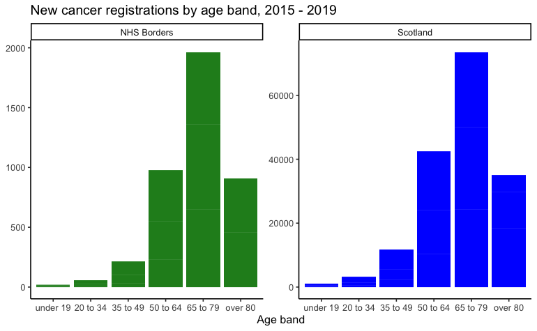

#### 3. Most common cancers

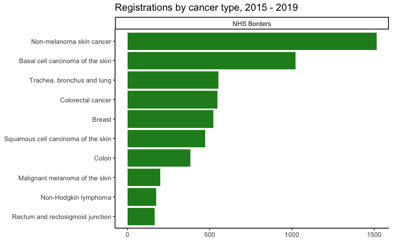

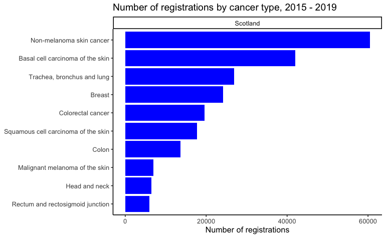

#### 4. Incidence rates of most common cancers

The plots below show the incidence *rates* of the most common types of cancer between 2015 and 2019, comparing rates between NHS Borders and Scotland. A visual inspection of the comparison shows that rates in NHS Borders are higher for some of these cancers. This suggests that further analysis could be carried out to understand the reasons for these differences.

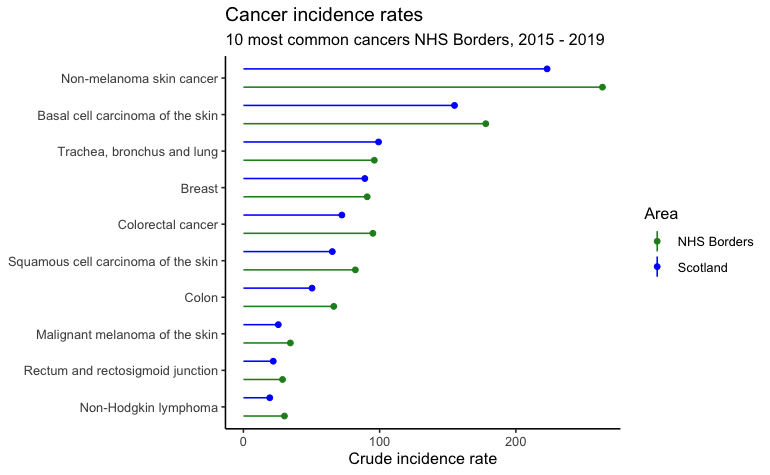